# Simulation setting

## Hormone Sensitive

### Treatment and biomarkers

3 active treatments: ARSi, Taxane_CT, PARPi  
5 biomarker signatures: all, TP53-, TP53+, HRD+, TEfus+  
8 biomarker subgroup combinations: —, –+, -+-, -++, +–, +-+, ++-, +++

**Prevelance of subgroup combinations**

| HRD | TP53 | TEfus | subtypes | prev | all | TP53- | TP53+ | HRD+ | TEfus+ |
| --- | --- | --- | --- | --- | --- | --- | --- | --- | --- |
| 0 | 0 | 0 | — | 0.30 | 1 | 1 | 0 | 0 | 0 |
| 0 | 0 | 1 | –+ | 0.09 | 1 | 1 | 0 | 0 | 1 |
| 0 | 1 | 0 | -+- | 0.19 | 1 | 0 | 1 | 0 | 0 |
| 0 | 1 | 1 | -++ | 0.14 | 1 | 0 | 1 | 0 | 1 |
| 1 | 0 | 0 | +– | 0.08 | 1 | 1 | 0 | 1 | 0 |
| 1 | 0 | 1 | +-+ | 0.08 | 1 | 1 | 0 | 1 | 1 |
| 1 | 1 | 0 | ++- | 0.06 | 1 | 0 | 1 | 1 | 0 |
| 1 | 1 | 1 | +++ | 0.06 | 1 | 0 | 1 | 1 | 1 |

**Prevelance of biomarker signatures**

[output not shown]

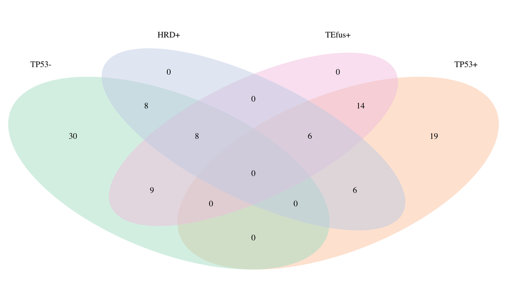

### Enrollment parameters

Enrollment and evaluation period: 60 months  
Accrual rate: 30 patients/month  
Standard-of-care (% treatment received): Other = 0.3; ARSi = 0.35; Taxane_CT = 0.35

**Initial randomization probabilities:**

|  | Control | ARSi | Taxane_CT | PARPi |
| --- | --- | --- | --- | --- |
| — | 0.37 | 0.37 | 0.25 | 0.00 |
| –+ | 0.38 | 0.19 | 0.38 | 0.06 |
| -+- | 0.41 | 0.18 | 0.41 | 0.00 |
| -++ | 0.41 | 0.12 | 0.41 | 0.06 |
| +– | 0.50 | 0.00 | 0.00 | 0.50 |
| +-+ | 0.50 | 0.00 | 0.00 | 0.50 |
| ++- | 0.50 | 0.00 | 0.00 | 0.50 |
| +++ | 0.50 | 0.00 | 0.00 | 0.50 |

|  | Control | ARSi | Taxane_CT | PARPi |
| --- | --- | --- | --- | --- |
| all | 0.45 | 0.11 | 0.18 | 0.27 |
| TP53- | 0.44 | 0.14 | 0.16 | 0.27 |
| TP53+ | 0.46 | 0.07 | 0.21 | 0.26 |
| HRD+ | 0.50 | 0.00 | 0.00 | 0.50 |
| TEfus+ | 0.45 | 0.08 | 0.20 | 0.28 |

### Stopping rules

| label | value | type | description |
| --- | --- | --- | --- |
| nupdate | 50.00 | Evaluation | Number of patients that need to be enrolled in the active arms before updating randomization probabilities |
| nval | 50.00 | Evaluation | Number of patients in a biomarker signature that need to be randomized to a treatment before if it gets evaluated for graduation |
| nmin | 10.00 | Evaluation | Same as before but for futility |
| nmin2 | 10.00 | Evaluation | Minimum number of patients in the subgroup combinations for evaluation (otherwise manual inspection from DSMB) |
| nmax | 300.00 | Stop nmax | Maximum number of patients for treatment-signature combination |
| pU | 0.85 | Graduation | Threshold for probability of superiority (graduation) in a treatment-signature combination |
| pU2 | 0.70 | Graduation | Threshold for probability of superiority (graduation) in a treatment-subgroup combination |
| pU2n | 0.60 | Graduation | Same as before, if treatment-subgroup combinations have lower sample size (nmin2) |
| pU2all | 0.55 | Graduation | Threshold for treatment-subgroup combinations (graduation) in the signature all |
| pL | 0.30 | Futility | Threshold for probability of superiority (futility) in a treatment-signature combination |
| pL2 | 0.50 | Futility | Threshold for probability of superiority (futility) in a treatment-subgroup combination |
| pL2n | 0.50 | Futility | Same as before, if treatment-subgroup combinations have lower sample size (nmin2) |
| pU2all | 0.55 | Futility | Threshold for treatment-subgroup combinations (futility) in the signature all |

### Priors and hyperparameters

- PFS is assumed to follow a Weibull distribution (shape, scale);
- PFS times were simulated from a Weibull distribution with shape = 1.3 and different possible values for the scale parameter (assumed treatment effect in the simulation scenarios);
- The survival models are parametrized as accelerated failure time models;
- The scale parameters are assumed to be linearly dependent on the treatment covariates;
- The following priors are adopted:
  - treatment covariates: normal (0, 0.5)
  - intercept term: normal (4, 1)
  - shape parameter: exponential (1)
- MCMC algorithm were implemented with 1 chain, 1000 of which 200 were used as warm-up.

## Castration Resistent

### Treatment and biomarkers

4 active treatments: ARSi, Taxane_CT, Platinum_CT, PARPi  
5 biomarker signatures: all, TP53- & AR-, TP53+, HRD+, TEfus+  
16 biomarker subgroup combinations: —-, —+, –+-, –++, -+–, -+-+, -++-, -+++, +—, +–+, +-+-, +-++, ++–, ++-+, +++-, ++++

**Prevelance of subgroup combinations**

| ARA | HRD | TP53 | TEfus | subtypes | prev | all | TP53- & AR- | TP53+ | HRD+ | TEfus+ |
| --- | --- | --- | --- | --- | --- | --- | --- | --- | --- | --- |
| 0 | 0 | 0 | 0 | —- | 0.25 | 1 | 1 | 0 | 0 | 0 |
| 0 | 0 | 0 | 1 | —+ | 0.05 | 1 | 1 | 0 | 0 | 1 |
| 0 | 0 | 1 | 0 | –+- | 0.15 | 1 | 0 | 1 | 0 | 0 |
| 0 | 0 | 1 | 1 | –++ | 0.10 | 1 | 0 | 1 | 0 | 1 |
| 0 | 1 | 0 | 0 | -+– | 0.05 | 1 | 1 | 0 | 1 | 0 |
| 0 | 1 | 0 | 1 | -+-+ | 0.05 | 1 | 1 | 0 | 1 | 1 |
| 0 | 1 | 1 | 0 | -++- | 0.03 | 1 | 0 | 1 | 1 | 0 |
| 0 | 1 | 1 | 1 | -+++ | 0.03 | 1 | 0 | 1 | 1 | 1 |
| 1 | 0 | 0 | 0 | +— | 0.05 | 1 | 0 | 0 | 0 | 0 |
| 1 | 0 | 0 | 1 | +–+ | 0.04 | 1 | 0 | 0 | 0 | 1 |
| 1 | 0 | 1 | 0 | +-+- | 0.04 | 1 | 0 | 1 | 0 | 0 |
| 1 | 0 | 1 | 1 | +-++ | 0.04 | 1 | 0 | 1 | 0 | 1 |
| 1 | 1 | 0 | 0 | ++– | 0.03 | 1 | 0 | 0 | 1 | 0 |
| 1 | 1 | 0 | 1 | ++-+ | 0.03 | 1 | 0 | 0 | 1 | 1 |
| 1 | 1 | 1 | 0 | +++- | 0.03 | 1 | 0 | 1 | 1 | 0 |
| 1 | 1 | 1 | 1 | ++++ | 0.03 | 1 | 0 | 1 | 1 | 1 |

**Prevelance of biomarker signatures**

| signatures | —- | —+ | –+- | –++ | -+– | -+-+ | -++- | -+++ | +— | +–+ | +-+- | +-++ | ++– | ++-+ | +++- | ++++ | prev |
| --- | --- | --- | --- | --- | --- | --- | --- | --- | --- | --- | --- | --- | --- | --- | --- | --- | --- |
| all | X | X | X | X | X | X | X | X | X | X | X | X | X | X | X | X | 1 |
| TP53- & AR- | X | X |  |  | X | X |  |  |  |  |  |  |  |  |  |  | 0.4 |
| TP53+ |  |  | X | X |  |  | X | X |  |  | X | X |  |  | X | X | 0.45 |
| HRD+ |  |  |  |  | X | X | X | X |  |  |  |  | X | X | X | X | 0.28 |
| TEfus+ |  | X |  | X |  | X |  | X |  | X |  | X |  | X |  | X | 0.37 |

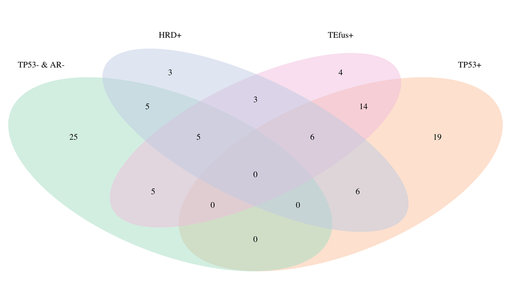

### Enrollment parameters

Enrollment and evaluation period: 36 months  
Accrual rate: 30 patients/month  
Standard-of-care (% treatment received): Other = 0.25; ARSi = 0.4; Taxane_CT = 0.35

**Initial randomization probabilities:**

|  | Control | ARSi | Taxane_CT | Platinum_CT | PARPi |
| --- | --- | --- | --- | --- | --- |
| —- | 0.44 | 0.44 | 0.11 | 0.00 | 0.00 |
| —+ | 0.35 | 0.35 | 0.29 | 0.00 | 0.00 |
| –+- | 0.33 | 0.33 | 0.17 | 0.08 | 0.08 |
| –++ | 0.41 | 0.18 | 0.41 | 0.00 | 0.00 |
| -+– | 0.33 | 0.00 | 0.00 | 0.33 | 0.33 |
| -+-+ | 0.33 | 0.00 | 0.00 | 0.33 | 0.33 |
| -++- | 0.33 | 0.00 | 0.00 | 0.33 | 0.33 |
| -+++ | 0.33 | 0.00 | 0.00 | 0.33 | 0.33 |
| +— | 0.41 | 0.18 | 0.41 | 0.00 | 0.00 |
| +–+ | 0.41 | 0.18 | 0.41 | 0.00 | 0.00 |
| +-+- | 0.37 | 0.12 | 0.37 | 0.06 | 0.06 |
| +-++ | 0.37 | 0.12 | 0.37 | 0.06 | 0.06 |
| ++– | 0.33 | 0.00 | 0.00 | 0.33 | 0.33 |
| ++-+ | 0.33 | 0.00 | 0.00 | 0.33 | 0.33 |
| +++- | 0.33 | 0.00 | 0.00 | 0.33 | 0.33 |
| ++++ | 0.33 | 0.00 | 0.00 | 0.33 | 0.33 |

|  | Control | ARSi | Taxane_CT | Platinum_CT | PARPi |
| --- | --- | --- | --- | --- | --- |
| all | 0.36 | 0.12 | 0.16 | 0.18 | 0.18 |
| TP53- & AR- | 0.37 | 0.20 | 0.10 | 0.17 | 0.17 |
| TP53+ | 0.35 | 0.09 | 0.17 | 0.19 | 0.19 |
| HRD+ | 0.33 | 0.00 | 0.00 | 0.33 | 0.33 |
| TEfus+ | 0.36 | 0.10 | 0.19 | 0.17 | 0.17 |

### Stopping rules

| label | value | type | description |
| --- | --- | --- | --- |
| nupdate | 50.00 | Evaluation | Number of patients that need to be enrolled in the active arms before updating randomization probabilities |
| nval | 25.00 | Evaluation | Number of patients in a biomarker signature that need to be randomized to a treatment before if it gets evaluated for graduation |
| nmin | 5.00 | Evaluation | Same as before but for futility |
| nmin2 | 5.00 | Evaluation | Minimum number of patients in the subgroup combinations for evaluation (otherwise manual inspection from DSMB) |
| nmax | 150.00 | Stop nmax | Maximum number of patients for treatment-signature combination |
| pU | 0.85 | Graduation | Threshold for probability of superiority (graduation) in a treatment-signature combination |
| pU2 | 0.70 | Graduation | Threshold for probability of superiority (graduation) in a treatment-subgroup combination |
| pU2n | 0.50 | Graduation | Same as before, if treatment-subgroup combinations have lower sample size (nmin2) |
| pU2all | 0.50 | Graduation | Threshold for treatment-subgroup combinations (graduation) in the signature all |
| pL | 0.30 | Futility | Threshold for probability of superiority (futility) in a treatment-signature combination |
| pL2 | 0.50 | Futility | Threshold for probability of superiority (futility) in a treatment-subgroup combination |
| pL2n | 0.50 | Futility | Same as before, if treatment-subgroup combinations have lower sample size (nmin2) |
| pU2all | 0.50 | Futility | Threshold for treatment-subgroup combinations (futility) in the signature all |

### Priors and hyperparameters

- PFS is assumed to follow a Weibull distribution (shape, scale);
- PFS times were simulated from a Weibull distribution with shape = 1.05 and different possible values for the scale parameter (assumed treatment effect in the simulation scenarios);
- The survival models are parametrized as accelerated failure time models;
- The scale parameters are assumed to be linearly dependent on the treatment covariates;
- The following priors are adopted:
  - treatment covariates: normal (0, 0.5)
  - intercept term: normal (3, 1)
  - shape parameter: exponential (1)
- MCMC algorithm were implemented with 1 chain, 1000 of which 200 were used as warm-up.